# Analyzing Algal Growth and Herbivore Interactions in Intertidal Zones: two way ANOVA

### ANOVA Analysis

Performing ANOVA analysis to assess the significance of interactions.

```r
anova(model_moo)
```

```
## Analysis of Variance Table
##
## Response: gain
##                 Df  Sum Sq Mean Sq F value    Pr(>F)
## diet             2 287.171 143.586 83.5201 2.999e-14 ***
## supplement       3  91.881  30.627 17.8150 2.952e-07 ***
## diet:supplement  6   3.406   0.568  0.3302    0.9166
## Residuals       36  61.890   1.719
## ---
## Signif. codes:  0 '***' 0.001 '**' 0.01 '*' 0.05 '.' 0.1 ' ' 1
```

### Model Summary

Summarizing the linear regression model.

```r
summary(model_moo)
```

```
##
## Call:
## lm(formula = gain ~ diet * supplement, data = data)
##
## Residuals:
##      Min       1Q   Median       3Q      Max
## -2.48756 -1.00368 -0.07452  1.03496  2.68069
##
## Coefficients:
##                                  Estimate Std. Error t value Pr(>|t|)
## (Intercept)                    20.4936649  0.6555863  31.260  < 2e-16 ***
## dietbarley                      2.8029851  0.9271390   3.023  0.00459 **
## dietwheat                      -3.0881467  0.9271390  -3.331  0.00201 **
## supplementagrimore              2.8047189  0.9271390   3.025  0.00457 **
## supplementsupergain            -0.8306614  0.9271390  -0.896  0.37624
## supplementsupersupp             1.3665697  0.9271390   1.474  0.14918
## dietbarley:supplementagrimore   0.2471088  1.3111726   0.188  0.85157
## dietwheat:supplementagrimore   -0.5711641  1.3111726  -0.436  0.66572
## dietbarley:supplementsupergain  0.0001351  1.3111726   0.000  0.99992
## dietwheat:supplementsupergain   0.4375746  1.3111726   0.334  0.74052
## dietbarley:supplementsupersupp  0.9120830  1.3111726   0.696  0.49113
## dietwheat:supplementsupersupp   0.8962530  1.3111726   0.684  0.49864
## ---
## Signif. codes:  0 '***' 0.001 '**' 0.01 '*' 0.05 '.' 0.1 ' ' 1
##
## Residual standard error: 1.311 on 36 degrees of freedom
## Multiple R-squared:  0.8607, Adjusted R-squared:  0.8182
## F-statistic: 20.22 on 11 and 36 DF,  p-value: 3.295e-12
```

### Adding Standard Error

Calculating standard errors and updating the summary with standard error values.

```r
sumMoo <- data %>%
  group_by(diet, supplement) %>%
  summarise(meanGrow = mean(gain), seGrow = sd(gain) / sqrt(n()))
sumMoo
```

```
## # A tibble: 12 x 4
## # Groups:   diet [3]
##    diet   supplement meanGrow seGrow
##    <fct>  <fct>         <dbl>  <dbl>
##  1 oats   control        20.5  0.506
##  2 oats   agrimore       23.3  0.613
##  3 oats   supergain      19.7  0.349
##  4 oats   supersupp      21.9  0.413
##  5 barley control        23.3  0.703
##  6 barley agrimore       26.3  0.919
##  7 barley supergain      22.5  0.771
##  8 barley supersupp      25.6  1.06
##  9 wheat  control        17.4  0.460
## 10 wheat  agrimore       19.6  0.710
## 11 wheat  supergain      17.0  0.485
## 12 wheat  supersupp      19.7  0.475
```

### Interaction Plot with Error Bars

Creating an interaction plot with error bars to show the mean cow weight gain along with the standard errors.

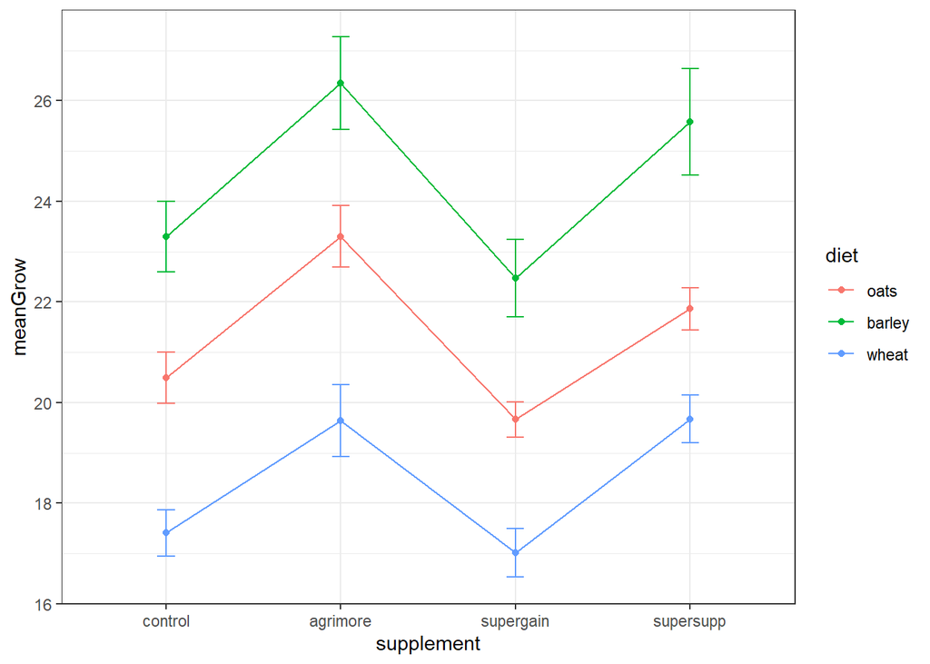

```r
ggplot(sumMoo, aes(x = supplement, y = meanGrow, colour = diet, group = diet)) +
  geom_point() +
  geom_line() +
  geom_errorbar(aes(ymin = meanGrow - seGrow, ymax = meanGrow + seGrow), width = 0.1) +
  theme_bw()
```

### Conclusion

In this analysis, we explored the effects of different diets and supplements on cow weight gain. The interaction plot and ANOVA results provided insights into the relationship between these variables and their impact on cow weight gain.